# Data Modelling Tutorial

Confidential: Property of the Data Jedi Academy, unauthorised distribution not allowed

[figure not shown]

## Data Modelling: Basic Introduction

### Introduction

Data doesn’t exist in a vacuum; understanding the relational nature of data is key to understanding its value. For example, what good would customer IDs be to a product team if those IDs didn’t coincide with the specific products that customers bought?

The process of assigning relational rules/relationships to data, such as that mentioned above, is called data modeling.

At a high level, data modeling is the process of visualizing and representing data for storage in a database or [data warehouse](https://www.ibm.com/cloud/learn/data-warehouse). The data model is a conceptual representation of the data, the relationships between data, and the rules. The modeling itself can include diagrams, symbols, or text to represent data and the way that it interrelates. [Data modelling](https://www.trifacta.com/blog/what-is-data-modeling/)

Content

1. Why Data Modelling
2. Data Modelling Components
3. Data Modelling Relationships
4. Types of Data Models
5. Dimensional Modelling and Data Warehousing

### 1. Why Data Modelling

The data model can have many purposes The classic purpose include:

- For developing a database as part of a system development project
- Act as an integral part of data warehousing
- Facilitate understanding of business rules

In Analytics, the foundation of building any analysis is to build a data model which helps you understand relationships between entities and business rules. For example in the model below, we can see the following:

- A shipped order is linked to a customer
- A shipped order is also linked to a product
- A product is linked to a product group
- A shipped order has a geographic location etc.

These will all be useful when we need to develop analytics or develop metrics to track for business reporting.

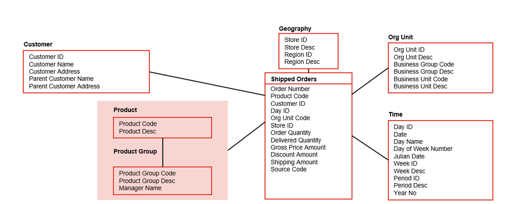

### 2. Data Modelling Components

A data model typically has the following components:

#### Entity -

A person, place, thing, event or concept that has characteristics of interest to the enterprise or business area.

#### Attribute -

An atomic (or non-decomposable) piece of information that describes an entity in some way. Also called data attribute, data item, data element, or property.

#### Primary key or identifier -

The primary attribute or combination of attributes that uniquely identify an occurrence of an entity.

#### Relationship -

A two-way association between entities expressing a business rule of interest to the enterprise or business area. Ex. Customer places one or many Orders

The diagram below provides relevant examples.

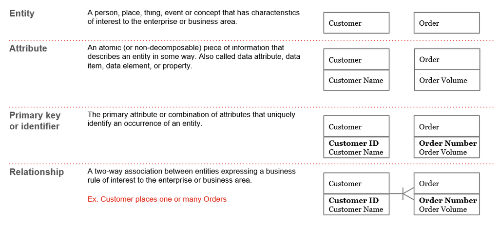

#### Primary Keys

The attribute or combination of attributes that uniquely identifies an occurrence of an entity. Primary keys or Identifiers must be unique so that they do not allow duplicate records.

#### a. Natural Keys -

Formed from attributes that are a part of the business functions and thus already exist in the data Ex. Social Security Number, Transaction Number

#### b. Surrogate Keys (used in data warehousing)-

When no natural keys are available or are not unique; artificial keys can be created Ex. Customer ID, Sequence ID

#### Foreign Keys

A Foreign Key is a data attribute in one entity that is the entire primary key of another entity. Foreign Keys are the basis upon which relationships are built.

For example below, the customer entity has a customer number which will be unique for each customer. Therefore this will be a primary key in the ustomer entity. However in the order entity, because a customer can have multiple orders, the customer number will appear many times making it a foreign key. The two keys can be linked to form a relationship for analysis.

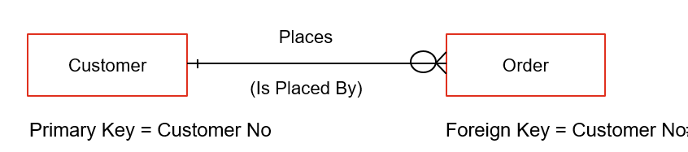

#### Referential Integrity

In each row of a relation containing a foreign key, the value of the foreign key either matches one of the values in the primary key column of the referred relation or the value of the foreign key is null (empty).

### 3. Data Modelling Relationship

Typically in a data model, entities are expected have relationships. These can be defined through symbols or cardinality.

#### Symbols:

Mandatory - Order Entity has to belong to Customer Entity Ex. There Cannot be an Order without a Customer

Optional - Customer does not need to have a Order. Ex. A Customer May or May not place an Order

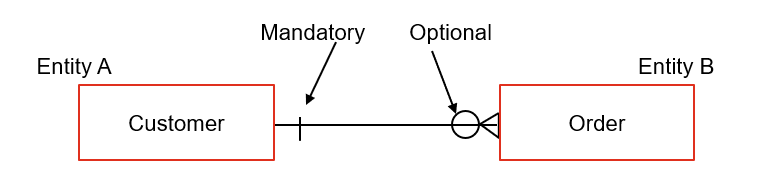

#### Cardinality

One - Order can only belong to one Customer Ex. An Order belongs to only one Customer. No split Orders.

Many - Customer can have multiple Order relationships. Ex. A Customer can place many Orders

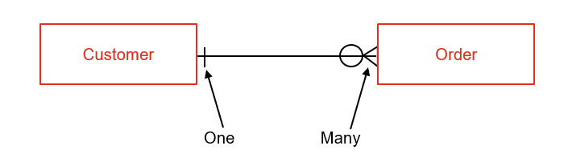

#### a. Types of cardinality

One-to-one (1:1): This is where an occurrence of an entity relates to just one occurrence in another entity. A one-to-one relationship seldom exists in practice, but it can. However, you will contemplate combining them into one entity.

For example: A Person can have only one Passport and each Passport belongs to only one Person.

One-to-many (1: M): In this relationship, one occurrence of an entity relates to many occurrences in another entity.

For example:A customer can have many orders.

[Types of cardinality](https://whatisdbms.com/what-is-cardinality-types-with-example-in-dbms/)

### 4. Types of Data Models

#### a. Conceptual Model

Contains major business entities, business relationships and may contain major attributes. Used as a planning tool at a business level or as initial project data model.

#### b. Logical Model

Contains all the data entities, all attributes and all data relationships. A complete model is accurate, detailed and identifies all the required data. A good model offers a number of options for the physical implementation.

#### c. Physical Model

Contains table names, columns, indexes, constraints as well as partitioning. This is the implementation model, targeting a specific physical DBMS, e.g. Microsoft SQL Server, DB2, Oracle, etc.

As a data analyst you will mostly work with conceptual models since tools such as PowerBI and other reporting tools provide a module for mapping relationships through conceptual models. You will hardly need to work with logical/physical models except in cases where you work with a database administrator to setup a database or work with a data engineer to setup a data warehouse.

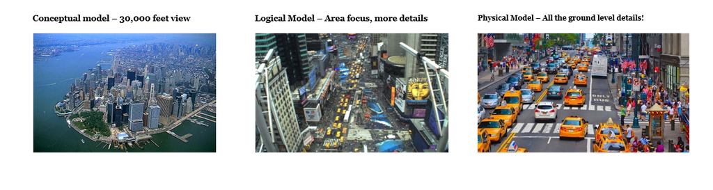

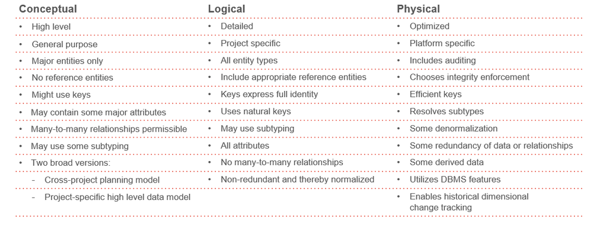

#### Sample Conceptual, Logical and Physical Models

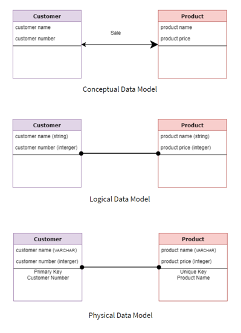

**Reference materials**

1. [Introduction to Data modelling](https://www.trifacta.com/blog/what-is-data-modeling/)
2. [Introduction to Data warehouse](https://www.ibm.com/cloud/learn/data-warehouse)
3. [Types of Data Models](https://www.guru99.com/data-modelling-conceptual-logical.html)
4. [Types of cardinality](https://whatisdbms.com/what-is-cardinality-types-with-example-in-dbms/)